# Text Predictor App Pitch

8/4/2020

This application takes an input of text of any length, and predict the following word. It also:

- Displays some common words and phrases that the model predicts on
- If the given word or phrase is not recognized by the application, it suggests the most common word in the training data, which in this case is the word "I'm"

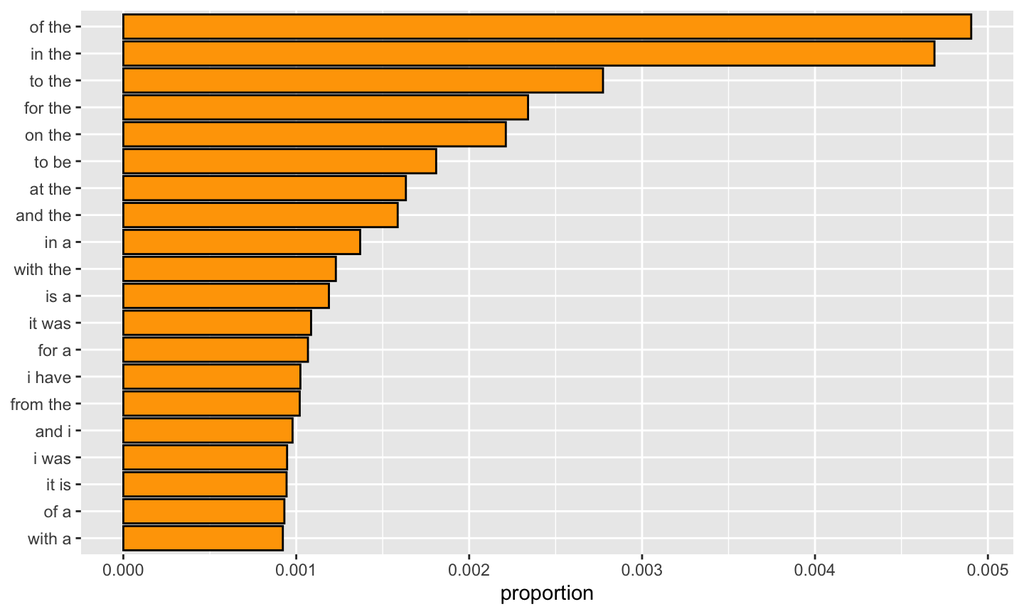

## The Model

This apllication uses a fuction that predicts using ngrams from the training data. Some features include:

- A backoff approach to writing the function
- Use of bigrams, trigrams, or quadgrams, depending on input text
- Use of a combination of the above, should the input text be longer than three words
- A default return of the most common word in the model ("I'm")
- A compact size that is able to run on most devices
- All words are predicted in lowercase lettering
- The application currently operates in the English language only

## The Data

This model was built using a subset of text from Twitter, blogs, and the news.

- Ten percent of each type of data was used to train the model
- This created the optimal size for both speed and accuracy
- A corpus was created first, and the ngrams were derived from there
- Profanity and slurs were omitted from the data so that they would not be predicted
- Symbols were removed and all words were coerced to lowercase

## Possible Future Improvements

With more available resources, this application could be expanded to include more phrases in its model. Other areas of growth include:

- Expanding the additional information provided by the application
- Possible inclusion of quantitative prediction accuracy statistics
- Increasing the number of words predicted for a given input
- Expanding the sources of initial data used, potentially including text messages and emails